# homework

SA22231079

2023.12.05

## Overview

The answers of the homework in this term.

## HW1

### Ex 1

Use the inverse transform to replicate part of sample (replace=TRUE) in a function named my.sample.

```r
mysample <- function(str=1,stp=100, num = 20){ #默认从1到100中有放回地随机挑选20个变量
  n = stp - str + 1
  x = seq(str, stp, 1)
  p = rep(1/n, n)
  Fu = c(0,cumsum(p));  #累加得到分布函数
  y = integer(num)
  m = length(Fu)
  u = runif(num)
  for(i in 1:m-1){   #逆转函数
    index = u>Fu[i] & u<=Fu[i+1];
    y[index]=x[i];
  };
  y
}
```

### 3.2

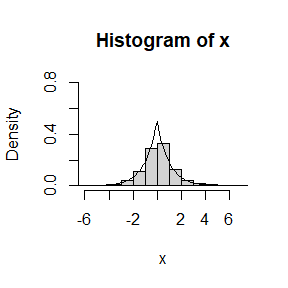

```r
U = runif(1000,0,1)
x = integer(1000)
for(i in 1:1000){      #reverse func
  if(U[i] > 0.5) {
    x[i] = -log(2-2*U[i])
    }
  else if(U[i] < 0.5) {
    x[i] = log(2*U[i])
      }
  else U[i] = 0.5
}
hist(x, prob = TRUE,ylim = c(0,0.8))  # Plot the frequency histogram for generating a random number x
xx = seq(-100,100,0.1)
lines(xx ,0.5 * exp(-abs(xx))) #Curve Fitting Controls
```

### 3.7

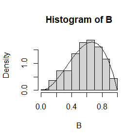

```r
myB <- function(n=1000,a=3,b=2){      #Default generation of 1000 random variables conforming to B(3, 2) distribution
  F <- function(x) (x^(a-1))*((1-x)^(b-1))
  Be = integrate(F,0,1)
  i=0
  x = integer(n)
  while(i<n)
  {
    u = runif(1)
    y = runif(1)
    if(F(y) > u){                     #A-C
      i = i+1
      x[i] = y
    }
  }
  x
}
B <- myB()
hist(B,prob=T)
xx = seq(0,1,0.01)
lines(xx,dbeta(xx,3,2)) # Curve Fitting Controls
```

### 3.9

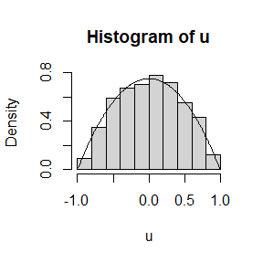

```r
F <- function(x) 0.75*(1-x^2)   #topic-specific recapitulation
n <- 1000
u <- integer(n)
for (i in 1:n) {
  u1 <- runif(n,-1,1)
  u2 <- runif(n,-1,1)
  u3 <- runif(n,-1,1)
  ifelse(abs(u3[i]) >= abs(u2[i]) && abs(u3[i]) >= abs(u1[i]),u[i] <- u2[i],
         u[i] <- u3[i])
}
hist(u, prob = TRUE)
x <- seq(-1, 1, 0.01)
lines(x, F(x))
```

## HW2

### Ex 1

Proof that what value $\rho=l/d$ should take to minimize the asymptotic variance of $\hat \pi$ (m~B(n,p),using $\delta$ method)

$we can see that \hat{\pi} = \frac{2l}{d\hat{p}}，through \delta method we can get that：$
$$Var(\hat\pi) = Var(\frac{2l}{d\hat{p}}) \approx
(\frac{d\hat{\pi}}{d\hat{p}})Var(\hat{p})=(-\frac{2l}{d{\hat{p}}^2})Var(\hat{p})$$
$$Var(\hat{p}) = Var(\frac{n}{m}) \approx
(\frac{d\hat{p}}{dm})Var(m)=(-\frac{n}{m^2})Var(m)=-\frac{n^2p(1-p)}{m^2}$$
So:
$$Var(\hat\pi) =(-\frac{2l}{d{\hat{p}}^2})(-\frac{n^2p(1-p)}{m^2})$$

### Ex 2

Take three different values of $\rho$ ($0 \leq \rho \leq 1$, including $\rho_{min}$) and use Monte Carlo simulation to verify your answer. (n = $10^6$, Number of repeated simulations K = 100)

```r
n <- 1E6
K <- 100

rho_1 <- 1.0  # ρmin
rho_2 <- 0.5  # ρ2
rho_3 <- 0.8  # ρ3

# simulate pi
simulate_pi <- function(rho) {
  pi_values <- numeric(K)
  for (i in 1:K) {
    m <- rbinom(1, n, rho)
    # calcu p_hat and pi_hat
    p_hat <- n / m
    pi_hat <- 2 * rho * p_hat
    pi_values[i] <- pi_hat
  }
  return(pi_values)
}


pi_values_1 <- simulate_pi(rho_1)
var_pi_1 <- var(pi_values_1)

pi_values_2 <- simulate_pi(rho_2)
var_pi_2 <- var(pi_values_2)

pi_values_3 <- simulate_pi(rho_3)
var_pi_3 <- var(pi_values_3)


print(paste("ρmin：", var_pi_1))
```

```
## [1] "ρmin： 0"
```

```r
print(paste("ρ2:", var_pi_2))
```

```
## [1] "ρ2: 3.4287353096141e-06"
```

```r
print(paste("ρ3:", var_pi_3))
```

```
## [1] "ρ3: 1.23041122736954e-06"
```

### 5.6

By $U ∼ Uniform(0,1)$ we can see：
$$E(e^U)=E(e^{1−U})=\int_{0}^{1} e^x dx=e-1$$
$$\begin{align*}
E(e^Ue^{1−U})=&\int_{0}^{1} e^x e^{1-x} dx\\
=&\int_{0}^{1} e^{1-x} de^x\\
=e\\
\end{align*}$$
$$Cov(e^U, e^{1−U}) =
E(e^Ue^{1−U})-E(e^U)E(e^{1−U})$$
By $Var(X)=E(X^2)-[E(X)]^2$ get that :
$$\begin{align*}
{Var}(e^U) &= E(e^{2U}) - [E(e^U)]^2 \\
&= \int_{0}^{1} e^{2x}dx - \left(\int_{0}^{1} e^{x}dx\right)^2 \\
&= \frac{4e - e^2 - 3}{2} = {Var}(e^{1-U})
\end{align*}$$
### 5.7

```r
m <- 1E4
simula <- function(){
  x <- runif(m, min=0, max=1)
  theta1.hat <<- mean(exp(x))
  x1 <- runif(m/2, min=0, max=1)
  theta2.hat <<- (mean(exp(x1))+mean(exp(1-x1)))/2
  true <- exp(1)-1
  c(theta1.hat,theta2.hat,true)
}
simula()
```

```
## [1] 1.722313 1.718397 1.718282
```

```r
V1 = integer(m)
V2 = integer(m)
for (i in 1:m){
  simula()
  V1[i] <- theta1.hat
  V2[i] <- theta2.hat
}

a <- var(V1)
b <- var(V2)
ans <- (a-b)/a
```

the answer is close to 0.9685652

## HW3

### 5.13

```r
m <- 1e4
f1 <- function(u)u^(1/4)
f2 <- function(u)exp(-(1/2*u^2))
set.seed(100)
u <- runif(m)
T1 <- f1(u)
T2 <- f2(u)
c(mean(T1), mean(T2))
```

```
## [1] 0.8008805 0.8557608
```

```r
c(sd(T1)/sqrt(m), sd(T2)/sqrt(m))
```

```
## [1] 0.001616692 0.001213804
```

### 5.14

```r
M <- 1e4
g = function (x) {
  x ^ 2 / sqrt(2*pi) * exp(-x^2/2) * (x > 1)
}

f1 = function (x) {
  dnorm(x, mean = 1.5) * (x > 1)
}
rf1 = function () {
  rnorm(M, mean = 1.5)
}
is_norm = function () {
  xs = rf1()
  return(mean(g(xs)/f1(xs), na.rm = TRUE))
}
(theta1 = is_norm())
```

```
## [1] 0.5804579
```

### 5.15

```r
M <- 10000
k <- 5
r <- M/k
N <- 50
T2 <- numeric(k)
est <- matrix(0, N, 2)
g<-function(t)(1-exp(-1))/(1+t^2)*(t>0)*(t<1)
for (i in 1:N) {
  est[i, 1] <- mean(g(runif(M)))
  for(j in 1:k)T2[j]<-mean(g(runif(M/k,(j-1)/k,j/k)))
  est[i, 2] <- mean(T2)
}
apply(est,2,mean)
```

```
## [1] 0.4961881 0.4964658
```

```r
apply(est,2,sd)
```

```
## [1] 0.0010250732 0.0001886665
```

### 6.5

```r
n <- 20
alpha <- .05
m <- 1000
mu1 <- 0
s1<-0
UCL <- USL <- numeric(m)
est <- matrix(0, m, 2)
for (i in 1:m) {
  y <- rnorm(n,mean = mu1,sd =2)
  est[i, 1] <- mean(y)
  est[i, 2] <- sqrt(var(y))* qt(1-alpha/2,df = n-1) / sqrt(n)
  UCL[i] <- est[i, 1] + est[i, 2]
  USL[i] <- est[i, 1] - est[i, 2]
  s1<-s1+(USL[i] < mu1 && mu1 < UCL[i] )
}
s1/m
```

```
## [1] 0.951
```

```r
mu2 <- 2
s2 <- 0
UCL <- USL <- numeric(m)
est <- matrix(0, m, 2)
for (i in 1:m) {
  y <- rchisq(n,df = 2)
  est[i, 1] <- mean(y)
  est[i, 2] <- sqrt(var(y))* qt(1-alpha/2,df = n-1) / sqrt(n)
  UCL[i] <- est[i, 1] + est[i, 2]
  USL[i] <- est[i, 1] - est[i, 2]
  s2<-s2+(USL[i] < mu2 && mu2 < UCL[i] )
}
s1/m
```

```
## [1] 0.951
```

```r
s2/m
```

```
## [1] 0.919
```

### 6.A

```r
P6A <- function(seed){
  set.seed(100)
  num<-c(50,100,200,500,1000)
  M<-10000
  er<-NULL
  for (n in num){
    cv<-qt(0.975,n-1)
    er1 <- 0
    er2 <- 0
    er3 <- 0
    for(i in 1:M){
      x<-rchisq(n,1)
      m<-mean(x)
      se<-sqrt(var(x))
      P<- abs((m-1)*sqrt(n)/se)>=cv
      er1 <- er1+P
    }
    er1 <- er1/M

    for(i in 1:M){
      x<-runif(n,0,2)
      m<-mean(x)
      se<-sqrt(var(x))
      P<- abs((m-1)*sqrt(n)/se)>=cv
      er2 <- er2+P
    }
    er2 <- er2/M

    for(i in 1:M){
      x<-rexp(n,1)
      m<-mean(x)
      se<-sqrt(var(x))
      P<- abs((m-1)*sqrt(n)/se)>=cv
      er3 <- er3+P
    }
    er3 <- er3/M

    er<-cbind(er,c(er1,er2,er3))
  }
  colnames(er)<-num
  rownames(er)<-c("chi(1)","U(0,2)","exp(1)")
  return(er)
}
P6A(1000)
```

```
##            50    100    200    500   1000
## chi(1) 0.0754 0.0672 0.0643 0.0533 0.0504
## U(0,2) 0.0512 0.0488 0.0503 0.0519 0.0508
## exp(1) 0.0668 0.0576 0.0518 0.0501 0.0465
```

## HW04

### Ex 1

```r
M <- 1000
alpha <- 0.1

# 初始化结果变量
FWER_bonf <- 0  # Bonferroni cue FWER
FDR_bh <- 0    # B-H cue FDR
TPR_bh <- 0    # B-H cue TPR

#simulate
for (i in 1:M) {
  m <- 1000
  p <- rep(0, m)

  for (j in 1:m) {
    if (runif(1) <= 0.95) {
      p[j] <- runif(1)
    } else {
      p[j] <- rbeta(1, 0.1, 1)
    }
  }

  # Bonferroni
  p_bonf <- p.adjust(p, method = "bonferroni")

  # B-H
  p_bh <- p.adjust(p, method = "BH")


  reject_bonf <- p_bonf <= alpha
  reject_bh <- p_bh <= alpha


  FWER_bonf <- FWER_bonf + sum(reject_bonf)
  FDR_bh <- FDR_bh + sum(reject_bh & !reject_bonf)
  TPR_bh <- TPR_bh + sum(reject_bh)
}


FWER_bonf <- FWER_bonf / (M * m)
FDR_bh <- FDR_bh / (M * m)
TPR_bh <- TPR_bh / (M * m)

# result
result <- matrix(c(FWER_bonf, NA, NA,
                   NA, FDR_bh, TPR_bh),
                 nrow = 2, ncol = 3,
                 dimnames = list(c("Bonferroni", "B-H"),
                                 c("FWER", "FDR", "TPR")))
print(result)
```

```
##                FWER FDR      TPR
## Bonferroni 0.019797  NA 0.011094
## B-H              NA  NA 0.030891
```

### Ex 2

```r
lambda <- 2
sample_sizes <- c(5, 10, 20)
B <- 1000
m <- 1000

mean_bias <- matrix(0, nrow = m, ncol = length(sample_sizes))  # Initialise the matrix storing the mean deviation
std_error <- matrix(0, nrow = m, ncol = length(sample_sizes))  # Initialise the matrix for storing standard errors

for (i in 1:m) {
  for (j in 1:length(sample_sizes)) {
    n <- sample_sizes[j]
    X <- rexp(n, rate = lambda)
    X_bar <- mean(X)

    # Resampling using the self-help method and calculating the MLE for each resample
    bootstrap_estimates <- replicate(B, 1/mean(sample(X, replace = TRUE)))
    mean_bias[i, j] <- mean(bootstrap_estimates) - lambda/(n-1)
    std_error[i, j] <- sqrt(n-2) * mean(bootstrap_estimates) * (n/(n-1))
  }
}

mean_bias_theoretical <- lambda/(sample_sizes - 1)  # theory deviation
std_error_theoretical <- lambda * sample_sizes / ((sample_sizes - 1) * sqrt(sample_sizes - 2))

mean_bias_mean <- apply(mean_bias, 2, mean)  # Mean value of average deviation
std_error_mean <- apply(std_error, 2, mean)  # Mean value of standard errors

mean_bias_theoretical  # output theory deviation
```

```
## [1] 0.5000000 0.2222222 0.1052632
```

```r
std_error_theoretical  # Output Theory Standard Error
```

```
## [1] 1.4433757 0.7856742 0.4962153
```

```r
mean_bias_mean  # Mean deviation of output self-help method
```

```
## [1] 2.515319 2.223748 2.095097
```

```r
std_error_mean  # Standard error of the mean of the output self-help method
```

```
## [1] 6.528358 7.686942 9.826670
```

### Ex 3

```r
library(boot)
library(bootstrap)
T_73 <- function(seed=1000){
  set.seed(seed)
  boot.t.ci <-
    function(x, B = 500, R = 100, level = .95, statistic){
      #compute the bootstrap t CI
      x <- as.matrix(x); n <- nrow(x)
      stat <- numeric(B); se <- numeric(B)
      boot.se <- function(x, R, f) {
        x <- as.matrix(x); m <- nrow(x)
        th <- replicate(R, expr = {i <- sample(1:m, size = m, replace = TRUE)
        f(x[i, ])})
        return(sd(th))
      }
      for (b in 1:B) {
        j <- sample(1:n, size = n, replace = TRUE)
        y <- x[j, ]
        stat[b] <- statistic(y)
        se[b] <- boot.se(y, R = R, f = statistic)
      }
      stat0 <- statistic(x)
      t.stats <- (stat - stat0) / se
      se0 <- sd(stat)
      alpha <- 1 - level
      Qt <- quantile(t.stats, c(alpha/2, 1-alpha/2), type = 1)
      names(Qt) <- rev(names(Qt))
      CI <- rev(stat0 - Qt * se0)
    }

  dat <- cbind(law$LSAT, law$GPA)
  stat <- function(dat){mean(cor(dat[,1],dat[,2]))}
  ci <- boot.t.ci(dat, statistic = stat, B=2000, R=200)
  print(ci)
}
T_73()
```

```
##       2.5%      97.5%
## -0.1603898  0.9979109
```

## HW05

### 7.5

Refer to Exercise 7.4. Compute 95% bootstrap confidence intervals for the mean time between failures 1/λ by the standard normal, basic, percentile,and BCa methods. Compare the intervals and explain why they may differ.

```r
library(boot)
hours = aircondit$hours
n = length(hours)
B = 200
#MLE
mle.lambda = function (values) {
  return(length(values)/sum(values))
}

time.b = numeric(B)
ts = numeric(B)

time.hat = 1/mle.lambda(hours)

# B times bootstrap sampler
for (b in 1:B) {
  i = sample(1:n, n, replace = TRUE)
  hours.b = hours[i]
  time.b[b] = 1/mle.lambda(hours.b)

  times.b2 = numeric(B)

  # Calculate parameter estimates for each bootstrap sample
  for (b2 in 1:B) {
    i2 = sample(1:n, n, replace = TRUE)
    hours.b2 = hours.b[i2]
    times.b2[b2] = 1/mle.lambda(hours.b2)
  }
  #Calculate the t-statistic for each bootstrap sample
  ts[b] = (time.b[b] - time.hat) / sd(times.b2)
}

#Calculate the standard error of the parameter estimates for the bootstrap sample
se.hat = sd(time.b)
alpha = 0.05;
q.probs = c(alpha/2, 1-alpha/2)

setCINames = function (object) {
  return(setNames(object, c(paste((alpha/2)*100, '%'), paste((1-alpha/2)*100, '%'))))
}

# Calculate confidence intervals for the standard normal distribution
q = qnorm(1-alpha/2)
ci.sn = time.hat + c(-1,1)*q*se.hat
(ci.sn = setCINames(ci.sn))
```

```
##     2.5 %    97.5 %
##  32.40494 183.76173
```

```r
# basic boostrap.
qs.time.hat = quantile(x = time.b, p = q.probs)
ci.basic = rev(2*time.hat - qs.time.hat)
(ci.basic = setCINames (object = ci.basic))
```

```
##    2.5 %   97.5 %
##  24.0125 167.5896
```

```r
(ci.percentile = qs.time.hat)
```

```
##      2.5%     97.5%
##  48.57708 192.15417
```

```r
# Bootstrap t method
qs.t = quantile(x = ts, p = q.probs)
(ci.t = setCINames(rev(time.hat - qs.t*se.hat)))
```

```
##     2.5 %    97.5 %
##  45.23157 285.79873
```

### 7.8

Refer to Exercise 7.7. Obtain the jackknife estimates of bias and standard error of θ.hat.

```r
set.seed(seed=100)
library(bootstrap)
sc<-scor
theta<-function(x){
  sigma<-cov(x)
  pca.sigma<-prcomp(sigma)
  theta<-pca.sigma$sdev[1]/sum(pca.sigma$sdev)
  theta
}
n<-NROW(sc)
theta.j<- numeric(n)
for (i in 1:n){
  theta.j[i]<-theta(sc[-i,])
}
theta.hat<-theta(sc)
bias<-(n-1)*(mean(theta.j)-theta.hat) #Bias
se<-sqrt((n-1)*var(theta.j)) #Se
round(c(bias,se),3)
```

```
## [1] 0.014 0.053
```

```r
list(Bias.jack=bias,SE.jack=se)
```

```
## $Bias.jack
## [1] 0.01433958
##
## $SE.jack
## [1] 0.05299504
```

### 7.11

In Example 7.18, leave-one-out (n-fold) cross validation was used to select the best fitting model. Use leave-two-out cross validation to compare the models.

```r
library(DAAG)
attach(ironslag)
n <- length(magnetic)
e1 <- e2 <- e3 <- e4 <- matrix(0,n,n)
for (i in 1:n) {

  for (j in (i+1):n-1){
    y <- magnetic[-c(i,j)]
    x <- chemical[-c(i,j)]

    J1 <- lm(y ~ x)
    yhat1 <- J1$coef[1] + J1$coef[2] * chemical[c(i,j)]
    e1[i,j] <- mean((magnetic[c(i,j)] - yhat1)^2)

    J2 <- lm(y ~ x + I(x^2))
    yhat2 <- J2$coef[1] + J2$coef[2] * chemical[c(i,j)] + J2$coef[3] *
      chemical[c(i,j)]^2
    e2[i,j] <- mean((magnetic[c(i,j)] - yhat2)^2)

    J3 <- lm(log(y) ~ x)
    logyhat3 <- J3$coef[1] + J3$coef[2] * chemical[c(i,j)]
    yhat3 <- exp(logyhat3)
    e3[i,j] <-mean(( magnetic[c(i,j)] - yhat3)^2)

    J4 <- lm(log(y) ~ log(x))
    logyhat4 <- J4$coef[1] + J4$coef[2] * log(chemical[c(i,j)])
    yhat4 <- exp(logyhat4)
    e4[i,j] <- mean((magnetic[c(i,j)] - yhat4)^2)

  }

}
c(2*sum(e1)/(n*(n-1)),2*sum(e2)/(n*(n-1)),2*sum(e3)/(n*(n-1)),2*sum(e4)/(n*(n-1)))
```

```
## [1] 18.50408 16.55759 17.06077 19.09614
```

## HW06

###Ex 1 Proof the Stationarity of Metropolis-Hastings sampler Algorithm in continuous situation.

if $π$ and $P$ ：
$$πP = P$$
Then the distribution $π$ is said to be the smooth distribution of a Markov chain with $P$ as the state transfer matrix. if :
$$\forall i,j\in S\qquad π_{i}P_{ij}=π_{j}P_{ji}$$
Then the state distribution $π$ is said to satisfy the meticulous smoothness condition for Markov chains. Based on the M-H principle of operation: (1)when $i\neq j$
$$P(X_{n+1}=j|X_n=i) = P(X_n=j|X_n=i) \cdot P(u \geq a_{ij}) +
P(Y=j|X_n=i) \cdot P(u < a_{ij}) \\= P(Y=j|X_n=i) \cdot P(u <
a_{ij}) = q_{ij} \cdot a_{ij}$$
(2)when $i= j$
$$P(X_{n+1}=j|X_n=i) = P(X_n=j|X_n=i) \cdot P(u \geq a_{ij}) +
P(Y=j|X_n=i) \cdot P(u < a_{ij}) \\= P(u \geq a_{ij}) + P(Y=j|X_n=i)
\cdot P(u < a_j) = 1 - a_{ij} + q_{ij} = q_{ij}$$
so，
$$p_{ij}=a_{ij}q_{ji}$$
$$\begin{aligned}
\pi_{i}p_{ij}& =\pi_iq_{ij}a_{ij} \\
&=\pi_iq_{ij}\min(1,\frac{\pi_jq_{ji}}{\pi_iq_{ij}}) \\
&=\min(\pi_iq_{ij},\pi_jq_{ji}) \\
&=\pi_jq_{ji}\min(1,\frac{\pi_iq_{ij}}{\pi_jq_{ji}}) \\
&=\pi_jq_{ji}a_{ji} \\
&=\pi_jp_{ji} \\
\end{aligned}$$

### 8.1

```r
attach(chickwts) # Attaching the chickwts dataset to the current environment

# Body weights of chickens fed with the two feed types were extracted separately and ranked
x <- sort(as.vector(weight[feed == "soybean"]))
y <- sort(as.vector(weight[feed == "linseed"]))

detach(chickwts)

library(cramer)
rep <- 1000

z <- c(x, y)
n1 <- length(x)
n2 <- length(y)
n <- n1 + n2

reps <- numeric(rep)

T.hat <-  cramer.test(x, y)$statistic


for (i in 1:rep) {
  # A set of n1 samples is randomly selected without playback from z
  k <- sample(1:n, n1, replace = FALSE)
  z1 <- z[k]
  z2 <- z[-k]
  reps[i] <- cramer.test(z1, z2)$statistic
}

p.hat <-  mean(abs(T.hat) < abs(reps))
p.hat
```

```
## [1] 0.358
```

[figure not shown]

```r
hist(reps, main = "", freq = FALSE, xlab = "T (P = 0.75)", breaks = "scott")
points(T.hat, 0, cex = 1, pch = 16)
```

### 8.3

```r
set.seed(100)
count5test <- function(x, y) {
  X <- x - mean(x)
  Y <- y - mean(y)
  weight <- round(10 * (length(x)/(length(x)+length(y))))
  outx <- sum(X > max(Y)) + sum(X < min(Y))
  outy <- sum(Y > max(X)) + sum(Y < min(X))
  # Calculate the number of X's greater than Y and the number of Y's less than Y, and the number of Y's greater than X and the number of Y's less than X, based on the extreme values of the samples X and Y
  return(as.integer(min(c(outx, outy)) > weight || max(c(outx, outy)) > (10-weight) )) #return 1 reject or 0 (receive H0)
}

R <- 10000
n1 <- 10
n2 <- 20
weight <- round(10 * (n1/(n1+n2)))
mu1 <- mu2 <- 0
sigma1 <- sigma2 <- 1
x <- rnorm(n1, mu1, sigma1)
y <- rnorm(n2, mu2, sigma2)

z <- c(x,y)
K <- 1:(n1 + n2)
n <- length(x)
jg <- numeric(R)
for (i in 1:R) {
  k <- sample(K, size = n, replace = FALSE)
  x1 <- z[k];y1 <- z[-k]
  x1 <- x1 - mean(x1) #centered by sample mean
  y1 <- y1 - mean(y1)
  jg[i] <- count5test(x1, y1)
}

q <- mean(jg) #Calculate the mean of the vector of experimental results jg, indicating the proportion of rejections of the null hypothesis
round(c(q),3) #A simulation experiment for comparing the difference between two normally distributed samples was performed by rejecting H0
```

```
## [1] 0.068
```

## HW07

### Ex 1

$$P(Y=1\mid
X_{1},X_{2},X_{3})=\frac{\exp(a+b_{1}X_{1}+b_{2}X_{2}+b_{3}X_{3})}{1+\operatorname{exp}(a+b_{1}X_{1}+b_{2}X_{2}+b_{3}X_{3})},\mathrm{where}X_{1}\sim
P(1)
，X_2\sim Exp(1)，X_3\sim B(1,0.5).$$
●Design a function that takes as input values N, b1, b2, b3 and f_0, and produces the output a.s ●Call this function, input values are N = 10E6,b1 =0,b2= 1,b3= -1, f_0 = 0.1, 0.01, 0.001, 0.0001. ●Plot-$\operatorname{log}f_0$ vs a

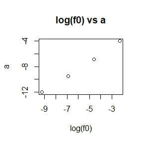

```r
ex1 <- function(N, b1, b2, b3, f_0) {
  X1 <- rbinom(N, 1, 1)
  X2 <- rexp(N, 1)
  X3 <- rbinom(N, 1, 0.5)
  #change traverse
  a <- log(f_0) - log(1 - log(f_0)) - b1 * mean(X1) - b2 * mean(X2) - b3 * mean(X3)

  return(a)
}

N <- 1e6
b1 <- 0
b2 <- 1
b3 <- -1
f_0_values <- c(0.1, 0.01, 0.001, 0.0001)

a_values <- c()
log_f_0_values <- c()

for (f_0 in f_0_values) {
  a <- ex1(N, b1, b2, b3, f_0)
  a_values <- c(a_values, a)
  log_f_0_values <- c(log_f_0_values, log(f_0))
}

plot(log_f_0_values, a_values, xlab = "log(f0)", ylab = "a", main = "log(f0) vs a")
```

### 9.4

```r
Metropolis <- function(n, sigma, x0, N) {
  x <- numeric(N)
  x[1] <- x0
  mu <- 1
  b <- 1
  u <- runif(N,-.5,.5)
  R <- mu-b*sign(u)*log(1-2*abs(u))
  k <- 0
  for (i in 2:N) {
    y <- rnorm(1, x[i-1], sigma)
    if (R[i] <= (dt(y, n) / dt(x[i-1], n)))
      x[i] <- y else {
        x[i] <- x[i-1]
        k <- k + 1
      } }
  return(list(x=x, k=k))
}
n <- 4 #t
N <- 2000
sigma <- c(.05, .5, 2, 5)
x0 <- 25
rp1 <- Metropolis(n, sigma[1], x0, N)
rp2 <- Metropolis(n, sigma[2], x0, N)
rp3 <- Metropolis(n, sigma[3], x0, N)
rp4 <- Metropolis(n, sigma[4], x0, N)
print(c(1-rp1$k/N, 1-rp2$k/N, 1-rp3$k/N, 1-rp4$k/N))
```

```
## [1] 0.5020 0.4710 0.4365 0.4125
```

### 9.7

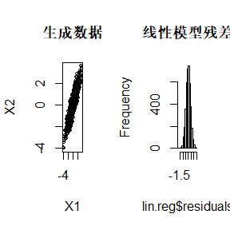

```r
m = 5000
burn = 1000

x = matrix(0, m, 2)

rho = 0.9
mu1 = 0
mu2 = 0
sigma1 = 1
sigma2 = 1
#Calculate the standard deviation to ensure that the generated data meets the set correlation
s1 = sqrt(1-rho^2)*sigma1
s2 = sqrt(1-rho^2)*sigma2
mean12 = function (x2) mu1 + rho*sigma1/sigma2*(x2 - mu2)
mean21 = function (x1) mu2 + rho*sigma2/sigma1*(x1 - mu1)
#Let the initial sample point be the mean
x[1,] = c(mu1, mu2)
#Generate residual samples
for (i in 2:m) {
  xt = x[i-1,]
  xt[1] = rnorm(1, mean12(xt[2]), s1)
  xt[2] = rnorm(1, mean21(xt[1]), s2)
  x[i,] = xt
}
#Discard the initial burn sample points and keep the remaining samples.
x = x[(burn+1):m,]

x = data.frame(x)
lin.reg = lm(X1 ~ X2, data = x)

par(mfrow=c(1,2))
plot(x, cex = 0.5, main = "生成数据")
hist(lin.reg$residuals, main = "线性模型残差")
```

```r
par(mfrow=c(1,1))
```

## 9.10

```r
rayleigh_pdf <- function(x, sigma) {
  if (any(x < 0)) return(0)
  stopifnot(sigma > 0)
  return(x / sigma^2 * exp(-x^2 / (2 * sigma^2)))
}

# Metropolis-Hastings
metropolis_hastings_sampler <- function(n, sigma, initial_value) {
  samples <- numeric(n)
  x <- initial_value

  for (i in 1:n) {
    y <- rnorm(1, mean = x, sd = 1)

    alpha <- rayleigh_pdf(y, sigma) / rayleigh_pdf(x, sigma)
    u <- runif(1)
    if (u <= alpha) {
      x <- y
    }
    samples[i] <- x
  }

  return(samples)
}

# Gelman-Rubin
gelman_rubin <- function(chains) {
  m <- length(chains)
  n <- min(sapply(chains, length))
  # Intercept all chains to the same length
  chains <- lapply(chains, function(x) x[1:n])
  # Calculate the mean value of each chain
  chain_means <- sapply(chains, mean)
  # Calculate the mean of all chains
  all_means <- colMeans(do.call(rbind, chains))

  B <- n * var(chain_means)

  W <- mean(sapply(chains, var))

  var_hat <- ((n - 1) / n) * W + (1 / n) * B
  #result
  R_hat <- sqrt(var_hat / W)

  return(R_hat)
}


sigma <- 4
initial_value <- 1
target_R_hat <- 1.2  # Gelman-Rubin

chains <- list()

while (TRUE) {
  samples <- metropolis_hastings_sampler(n = 10000, sigma = sigma, initial_value = initial_value)

  chains <- c(chains, list(samples))

  # Gelman-Rubin
  R_hat <- gelman_rubin(chains)

  # Check that convergence conditions are met
  if (!is.na(R_hat) && R_hat < target_R_hat) {
    break
  }

  # Update initial sample values
  initial_value <- samples[length(samples)]
}

print(paste("Final R_hat:", R_hat))
```

```
## [1] "Final R_hat: 1.00096183061748"
```

## HW08

### Ex 1

1. The likelihood function for the observed data is
   $$L(\lambda) = \prod_{i=1}^{n} P_\lambda(u_i \leq X_i \leq v_i)$$
   For each $X_i$, we have the following conditional probabilities:
   $$P_\lambda(u_i \leq X_i \leq v_i) = P_\lambda(X_i \geq u_i) -
   P_\lambda(X_i \geq v_i) = e^{-\lambda u_i} - e^{-\lambda v_i}$$
   The likelihood function for the observed data is
   $$L(\lambda) = \prod_{i=1}^{n} P_\lambda(u_i \leq X_i \leq
   v_i)=\prod_{i=1}^{n} (e^{-\lambda u_i} - e^{-\lambda v_i})$$
   Take the logarithm of the likelihood function:

$$\log L(\lambda) = \sum_{i=1}^{n} \log(e^{-\lambda u_i} - e^{-\lambda
v_i})$$
1. Likelihood function for maximised observations

To solve for the MLE of $\lambda$, we need to maximise the likelihood function for the observed data. Taking logarithms and solving for $\lambda$, we can obtain the likelihood equation:
$$\frac{\partial \log L(\lambda)}{\partial \lambda} = \sum_{i=1}^{n}
\left( \frac{v_i e^{-\lambda v_i} - u_i e^{-\lambda u_i}}{-e^{-\lambda
u_i} + e^{-\lambda v_i}} \right) = 0$$
2. Using the EM algorithm The log-likelihood function for the observed data is
$$\log L(\lambda) = \sum_{i=1}^{n} \log(e^{-\lambda u_i} - e^{-\lambda
v_i})$$
The log-likelihood function for complete data is：

$$\log L(\lambda) = \sum_{i=1}^{n} \log P(X_i, Z_i | \lambda)$$

where $X_i$ denotes the observed data;

$Z_i$ denotes the corresponding implicit variable indicating whether $X_i$ falls in the given interval $(u_i,v_i)$ (if $X_i$ falls in the interval, $Z_i = 1$; otherwise, $Z_i = 0$);

$\lambda$ denotes the parameters of the model。

E step（Expectation Step）：

Calculate the expectation $\hat{Z}_i$ of the hidden variable $Z_i$, for the $i$th observation $X_i$, with：
$$\hat{Z}_i = P(Z_i = 1 | X_i, \lambda^{(t)}) = \frac{P(u_i < X_i <
v_i | \lambda^{(t)})}{P(X_i > u_i | \lambda^{(t)}) - P(X_i > v_i |
\lambda^{(t)})}$$
where $\lambda^{(t)}$ denotes the $\lambda$ value of the current iteration。

M step（Maximization Step）：

Update the parameter $\lambda$ using the observed data and the expectations of the hidden variables. Specifically, maximise the log-likelihood function for the complete data：
$$\lambda^{(t+1)} = \arg\max_\lambda \sum_{i=1}^{n} \left( \hat{Z}_i \log
f(X_i;\lambda) \right)$$
where $f(x;\lambda)$ is the probability density function of the exponential distribution

Repeat steps E and M until $\lambda$ converges, stop iteration

3. prove that It is shown that the EM algorithm converges to the MLE of the observed data and has linear speed: For the EM algorithm to converge, the following two conditions need to be satisfied:
   1. the expectation of the log-likelihood function for complete data (corresponding to the E-step) is a convex function.
   2. In step M, we can find the parameter values that maximise the expectation of the log-likelihood function for complete data. The log-likelihood function for complete data can be expressed as：
      $$\log L_c(\lambda) = \sum_{i=1}^{n} \log f(X_i;\lambda) = \sum_{i=1}^{n}
      \left( \hat{Z}_i \log f(X_i;\lambda) \right)$$
      where $\hat{Z}_i$ is the expectation of the hidden variable $Z_i$ computed in the E-step.

Using Jensen’s inequality, we know that for convex functions, there are
$$\mathbb{E}[g(X)] \geq
g(\mathbb{E}[X])$$
Since the function $g(x) = \log x$ is convex, we have that：

$$\sum_{i=1}^{n} \left( \hat{Z}i \log f(X_i;\lambda) \right) \geq \log
\left( \sum{i=1}^{n} \left( \hat{Z}_i f(X_i;\lambda) \right) \right)$$
The value of the log-likelihood function for complete data monotonically increases in each iteration. Since the log-likelihood function for complete data is upper bounded, the EM algorithm converges.

In addition, each iteration increases the value of the log-likelihood function for the complete data, so the EM algorithm has a linear rate of convergence.

(2)if $(u_i, v_i), i=1,...,n(n=10)$ are obversed as (11, 12), (8, 9), (27, 28), (13, 14), (16, 17), (0, 1), (23, 24), (10, 11), (24, 25), (2, 3)Try to implement the above two algorithms separately to get the numerical solution of the MLE of $\lambda$.

```r
data <- matrix(c(11, 12,
                 8, 9,
                 27, 28,
                 13, 14,
                 16, 17,
                 0, 1,
                 23, 24,
                 10, 11,
                 24, 25,
                 2, 3), ncol = 2, byrow = TRUE)

MLE <- function(lambda) {
  u <- data[, 1]
  v <- data[, 2]


  log_likelihood <- sum(log(exp(-lambda * u) - exp(-lambda * v)))

  return(-log_likelihood) # Minimisation using negative log-likelihood function with optim function
}

a1 <- optim(par = 1, fn = MLE, method = "Brent", lower = 0, upper = 10)

cat("直接极大似然估计结果：", a1$par, "\n")
```

```
## 直接极大似然估计结果： 0.0719735
```

```r
EM <- function(data, max_iter = 10000, tol = 1e-6) {
  n <- nrow(data)
  lambda <- 1

  for (iter in 1:max_iter) {
    lambda_prev <- lambda

    # E
    z <- (exp(-lambda * data[, 1]) - exp(-lambda * data[, 2])) / (exp(-lambda * data[, 1]) - exp(-lambda * data[, 2]))

    # M
    lambda <- optimize(f = function(x) {
      sum(z * log(1 / x) + (1 - z) * log(-exp(-x * data[, 2]) + exp(-x * data[, 1])))
    }, interval = c(0, 10), maximum = FALSE)$minimum

    if (abs(lambda - lambda_prev) < tol) {
      break
    }
  }

  return(lambda)
}


a2 <- EM(data)


cat("EM算法估计结果：", a2, "\n")
```

```
## EM算法估计结果： 9.999944
```

### Ex 2

In the Morra game, the set of optimal strategies are not changed if a constant is subtracted from every entry of the payoﬀ matrix, or a positive constant is multiplied times every entry of the payoﬀ matrix. However, the simplex algorithm may terminate at a diﬀerent basic feasible point (also optimal). Compute B <- A + 2, ﬁnd the solution of game B, and verify that it is one of the extreme points (11.12)–(11.15) of the original game A. Also ﬁnd the value of game A and game B.

```r
library(boot)
# Create payment matrix A
A <- matrix(c( 0,-2,-2,3,0,0,4,0,0,
               2,0,0,0,-3,-3,4,0,0,
               2,0,0,3,0,0,0,-4,-4,
               -3,0,-3,0,4,0,0,5,0,
               0,3,0,-4,0,-4,0,5,0,
               0,3,0,0,4,0,-5,0,-5,
               -4,-4,0,0,0,5,0,0,6,
               0,0,4,-5,-5,0,0,0,6,
               0,0,4,0,0,5,-6,-6,0), 9, 9)
B <- A + 2

solve.game <- function(A){
  # Solving a zero-sum game with two players using the simplex method
  # Optimise player 1 first, optimise player 2 later


  min.A <- min(A)
  A <- A - min.A # v >= 0
  max.A <- max(A)
  A <- A / max(A)

  m <- nrow(A)
  n <- ncol(A)
  it <- n^3

  # Player 1 optimisation
  a <- c(rep(0, m), 1)
  A1 <- -cbind(t(A), rep(-1, n))
  b1 <- rep(0, n)
  A3 <- t(as.matrix(c(rep(1, m), 0)))
  b3 <- 1
  sx <- simplex(a=a, A1=A1, b1=b1, A3=A3, b3=b3, maxi=TRUE, n.iter=it)

  # Player 2 optimisation
  a <- c(rep(0, n), 1)
  A1 <- cbind(A, rep(-1, m))
  b1 <- rep(0, m)
  A3 <- t(as.matrix(c(rep(1, n), 0)))
  b3 <- 1
  sy <- simplex(a = a, A1 = A1, b1 = b1, A3 = A3, b3 = b3, maxi = FALSE, n.iter = it)

  # 构造结果
  soln <- list(
    "A" = A * max.A + min.A,  # 恢复原始范围的支付矩阵A
    "x" = sx$soln[1:m],  # Player 1's strategy vector x
    "y" = sy$soln[1:n],  # Player 2's strategy vector x
    "v" = sx$soln[m + 1] * max.A + min.A,  # The value of the game v
    "optimal_point" = cbind(sx$soln[1:m], sy$soln[1:n])
  )

  return(soln)
}

soln_A <- solve.game(A)
soln_B <- solve.game(B)
round(soln_A$optimal_point, 7)
```

```
##         [,1]      [,2]
## x1 0.0000000 0.0000000
## x2 0.0000000 0.0000000
## x3 0.4098361 0.4098361
## x4 0.0000000 0.0000000
## x5 0.3278689 0.3278689
## x6 0.0000000 0.0000000
## x7 0.2622951 0.2622951
## x8 0.0000000 0.0000000
## x9 0.0000000 0.0000000
```

```r
round(soln_A$v, 7)
```

```
## x10
##   0
```

```r
round(soln_B$optimal_point, 7)
```

```
##         [,1]      [,2]
## x1 0.0000000 0.0000000
## x2 0.0000000 0.0000000
## x3 0.4098361 0.4098361
## x4 0.0000000 0.0000000
## x5 0.3278689 0.3278689
## x6 0.0000000 0.0000000
## x7 0.2622951 0.2622951
## x8 0.0000000 0.0000000
## x9 0.0000000 0.0000000
```

```r
round(soln_B$v, 7)
```

```
## x10
##   2
```

## HW09

### 2.1.3 ex4

Why do you need to use unlist() to convert a list to an atomic vector? Why doesn’t as.vector() work?

```r
# In R, the unlist() function is used to convert lists into atomic vectors by combining all the elements of a list into a single vector, while the as.vector() function is mainly used to force conversions and cannot directly convert lists into atomic vectors.
#The main reason for using unlist() instead of as.vector() is that unlist() is specifically designed to flatten a list structure and concatenate its elements into a single vector. It recursively traverses the list and extracts each element, preserving their order. This feature of unlist() is critical when there are nested lists with multiple levels of nesting and you want to collapse them into a single vector.
#as.vector() is primarily used for forced conversions, where it attempts to convert objects into vectors of the appropriate pattern. It is useful for converting other data types (such as matrices or arrays) to vector form. However, when it comes to lists, as.vector() does not automatically flatten the list structure. It can only force a list to be converted to a vector of type "list", where each element of the resulting vector is a list.
```

### 2.3.1 ex1

What does dim() return when applied to a vector?

```r
#dim() function is used to retrieve or set the dimension of an object, such as a matrix or array. When applied to a vector, the dim() function returns NULL.
# In R, a vector is considered a one-dimensional object that represents a sequence of elements with the same data type. Since vectors do not have multiple dimensions like matrices or arrays, the dim() function does not have any meaningful dimensions to return.
dim(c(1, 2, 3))
```

[output not shown]

### 2.3.1 ex2

If is.matrix(x) is TRUE, what will is.array(x) return?

```r
# Again, TRUE, the array is a multidimensional matrix.
x <- matrix(1:4, nrow = 2)
is.matrix(x)
```

```
## [1] TRUE
```

```r
is.array(x)
```

```
## [1] TRUE
```

### 2.4.5 ex2

What does as.matrix() do when applied to a data frame with columns of different types?

```r
# Forced type conversion occurs and the resulting matrix will be a character matrix
df <- data.frame(A = c(1, 2, 3), B = c("a", "b", "c"), C = c(TRUE, FALSE, TRUE))

matrix <- as.matrix(df)

print(matrix)
```

```
##      A   B   C
## [1,] "1" "a" "TRUE"
## [2,] "2" "b" "FALSE"
## [3,] "3" "c" "TRUE"
```

```r
print(class(matrix))
```

```
## [1] "matrix" "array"
```

### 2.4.5 ex3

Can you have a data frame with 0 rows? What about 0 columns?

```r
#yes
#The number of rows and columns is 0
empty_df <- data.frame()

num_rows <- nrow(empty_df)
num_cols <- ncol(empty_df)

print(num_rows)
```

```
## [1] 0
```

```r
print(num_cols)
```

```
## [1] 0
```

```r
#rows are 0
df <- data.frame(1, seq(10))[FALSE, ]
dim(df)
```

```
## [1] 0 2
```

```r
#cols are 0
df <- data.frame(1, seq(10))[, FALSE]
dim(df)
```

```
## [1] 10  0
```

### ex2 P204

The function below scales a vector so it falls in the range [0,1]. How would you apply it to every column of a data frame? How would you apply it to every numeric column in a data frame?

```r
#scale01 <- function(x) {
#  rng <- range(x, na.rm = TRUE)
#  (x - rng[1]) / (rng[2] - rng[1])
#}
```

How would you apply it to every column of a data frame?

```r
scale01 <- function(x) {
  rng <- range(x, na.rm = TRUE)
  (x - rng[1]) / (rng[2] - rng[1])
}
lapply(mtcars, scale01)
```

```
## $mpg
##  [1] 0.4510638 0.4510638 0.5276596 0.4680851 0.3531915 0.3276596 0.1659574
##  [8] 0.5957447 0.5276596 0.3744681 0.3148936 0.2553191 0.2936170 0.2042553
## [15] 0.0000000 0.0000000 0.1829787 0.9361702 0.8510638 1.0000000 0.4723404
## [22] 0.2170213 0.2042553 0.1234043 0.3744681 0.7191489 0.6638298 0.8510638
## [29] 0.2297872 0.3957447 0.1957447 0.4680851
##
## $cyl
##  [1] 0.5 0.5 0.0 0.5 1.0 0.5 1.0 0.0 0.0 0.5 0.5 1.0 1.0 1.0 1.0 1.0 1.0 0.0 0.0
## [20] 0.0 0.0 1.0 1.0 1.0 1.0 0.0 0.0 0.0 1.0 0.5 1.0 0.0
##
## $disp
##  [1] 0.22175106 0.22175106 0.09204290 0.46620105 0.72062859 0.38388626
##  [7] 0.72062859 0.18857570 0.17385882 0.24070841 0.24070841 0.51060115
## [13] 0.51060115 0.51060115 1.00000000 0.97006735 0.92017960 0.01895735
## [19] 0.01147418 0.00000000 0.12222499 0.61586431 0.58094288 0.69568471
## [25] 0.82040409 0.01970566 0.12272387 0.05986530 0.69817910 0.18433525
## [31] 0.57345972 0.12446994
##
## $hp
##  [1] 0.20494700 0.20494700 0.14487633 0.20494700 0.43462898 0.18727915
##  [7] 0.68197880 0.03533569 0.15194346 0.25088339 0.25088339 0.45229682
## [13] 0.45229682 0.45229682 0.54063604 0.57597173 0.62897527 0.04946996
## [19] 0.00000000 0.04593640 0.15901060 0.34628975 0.34628975 0.68197880
## [25] 0.43462898 0.04946996 0.13780919 0.21554770 0.74911661 0.43462898
## [31] 1.00000000 0.20141343
##
## $drat
##  [1] 0.52534562 0.52534562 0.50230415 0.14746544 0.17972350 0.00000000
##  [7] 0.20737327 0.42857143 0.53456221 0.53456221 0.53456221 0.14285714
## [13] 0.14285714 0.14285714 0.07834101 0.11059908 0.21658986 0.60829493
## [19] 1.00000000 0.67281106 0.43317972 0.00000000 0.17972350 0.44700461
## [25] 0.14746544 0.60829493 0.76958525 0.46543779 0.67281106 0.39631336
## [31] 0.35944700 0.62211982
##
## $wt
##  [1] 0.28304781 0.34824853 0.20634109 0.43518282 0.49271286 0.49782664
##  [7] 0.52595244 0.42879059 0.41856303 0.49271286 0.49271286 0.65379698
## [13] 0.56686269 0.57964715 0.95551010 1.00000000 0.97980056 0.17565840
## [19] 0.02608029 0.08233188 0.24341601 0.51316799 0.49143442 0.59498849
```

[output cut: 12 more lines]

```
##  [1] 0 0 1 1 0 1 0 1 1 1 1 0 0 0 0 0 0 1 1 1 1 0 0 0 0 1 0 1 0 0 0 1
##
## $am
##  [1] 1 1 1 0 0 0 0 0 0 0 0 0 0 0 0 0 0 1 1 1 0 0 0 0 0 1 1 1 1 1 1 1
##
## $gear
##  [1] 0.5 0.5 0.5 0.0 0.0 0.0 0.0 0.5 0.5 0.5 0.5 0.0 0.0 0.0 0.0 0.0 0.0 0.5 0.5
## [20] 0.5 0.0 0.0 0.0 0.0 0.0 0.5 1.0 1.0 1.0 1.0 1.0 0.5
##
## $carb
##  [1] 0.4285714 0.4285714 0.0000000 0.0000000 0.1428571 0.0000000 0.4285714
##  [8] 0.1428571 0.1428571 0.4285714 0.4285714 0.2857143 0.2857143 0.2857143
## [15] 0.4285714 0.4285714 0.4285714 0.0000000 0.1428571 0.0000000 0.0000000
## [22] 0.1428571 0.1428571 0.4285714 0.1428571 0.0000000 0.1428571 0.1428571
## [29] 0.4285714 0.7142857 1.0000000 0.1428571
```

How would you apply it to every numeric column in a data frame?

```r
scale01 <- function(x) {
  rng <- range(x, na.rm = TRUE)
  (x - rng[1]) / (rng[2] - rng[1])
}
#As an example, the Iris dataset
iris[sapply(iris, is.numeric)]#Selection series
```

```
##     Sepal.Length Sepal.Width Petal.Length Petal.Width
## 1            5.1         3.5          1.4         0.2
## 2            4.9         3.0          1.4         0.2
## 3            4.7         3.2          1.3         0.2
## 4            4.6         3.1          1.5         0.2
## 5            5.0         3.6          1.4         0.2
## 6            5.4         3.9          1.7         0.4
## 7            4.6         3.4          1.4         0.3
## 8            5.0         3.4          1.5         0.2
## 9            4.4         2.9          1.4         0.2
## 10           4.9         3.1          1.5         0.1
## 11           5.4         3.7          1.5         0.2
## 12           4.8         3.4          1.6         0.2
## 13           4.8         3.0          1.4         0.1
## 14           4.3         3.0          1.1         0.1
```

[output cut: 136 more lines]

```r
lapply(iris[sapply(iris, is.numeric)], scale01)
```

```
## $Sepal.Length
##   [1] 0.22222222 0.16666667 0.11111111 0.08333333 0.19444444 0.30555556
##   [7] 0.08333333 0.19444444 0.02777778 0.16666667 0.30555556 0.13888889
##  [13] 0.13888889 0.00000000 0.41666667 0.38888889 0.30555556 0.22222222
##  [19] 0.38888889 0.22222222 0.30555556 0.22222222 0.08333333 0.22222222
##  [25] 0.13888889 0.19444444 0.19444444 0.25000000 0.25000000 0.11111111
##  [31] 0.13888889 0.30555556 0.25000000 0.33333333 0.16666667 0.19444444
##  [37] 0.33333333 0.16666667 0.02777778 0.22222222 0.19444444 0.05555556
##  [43] 0.02777778 0.19444444 0.22222222 0.13888889 0.22222222 0.08333333
##  [49] 0.27777778 0.19444444 0.75000000 0.58333333 0.72222222 0.33333333
##  [55] 0.61111111 0.38888889 0.55555556 0.16666667 0.63888889 0.25000000
##  [61] 0.19444444 0.44444444 0.47222222 0.50000000 0.36111111 0.66666667
##  [67] 0.36111111 0.41666667 0.52777778 0.36111111 0.44444444 0.50000000
##  [73] 0.55555556 0.50000000 0.58333333 0.63888889 0.69444444 0.66666667
##  [79] 0.47222222 0.38888889 0.33333333 0.33333333 0.41666667 0.47222222
```

[output cut: 92 more lines]

### ex1 P213

Use vapply() to: a) Compute the standard deviation of every column in a numeric data frame. b) Compute the standard deviation of every numeric column in a mixed data frame. (Hint: you’ll need to use vapply() twice.)

```r
#a
df<-data.frame(x=c(1,2,3),y=c(4,4,5))
df
```

```
##   x y
## 1 1 4
## 2 2 4
## 3 3 5
```

```r
vapply(df,sd,FUN.VALUE = 1)
```

```
##         x         y
## 1.0000000 0.5773503
```

```r
#b
df<-data.frame(x=c(1,2,3),y=c(4,4,5))
df$z<-c("A","B","C")
df
```

```
##   x y z
## 1 1 4 A
## 2 2 4 B
## 3 3 5 C
```

```r
vapply(df[vapply(df,is.numeric,TRUE)],sd,1)
```

```
##         x         y
## 1.0000000 0.5773503
```

### 9.8

The source R code are as follows:

```r
#R code:
GibbsR <- function(N,thin,a,b,n){
  mat <- matrix(nrow = N, ncol = 2)
  x <-rbinom(1,prob=0.5,size=n)
  y <-rbeta(1,x+a,n-x+b)
  for (i in 1:N) {
    for (j in 1:thin) {
      x <- rbinom(1,prob = y, size = n)
      y <- rbeta(1,x+ a, n - x+ b)
    }
    mat[i, ] <- c(x, y)
  }
  mat
}

#The C++ code:
library(Rcpp)
#include <Rcpp.h>
using namespace Rcpp;

// [[Rcpp::export]]
NumericMatrix GibbsC(int N, int thin, int a, int b,int n) {
   NumericMatrix mat(N, 2);
   double x = rbinom(1,0.5,n)[0];
   double y = rbeta(1,x+a,n-x+b)[0];
   for(int i = 0; i < N; i++) {
     for(int j = 0; j < thin; j++) {
       x = rbinom(1,y,n)[0];
       y = rbeta(1,x+a,n-x+b)[0];
     }
     mat(i, 0) = x;
     mat(i, 1) = y;
   }
   return(mat);
}

library(microbenchmark)
tm1 <- microbenchmark::microbenchmark(
rnR = GibbsR(1e3,10,2,3,10),
rnC = GibbsC(1e3,10,2,3,10)
 )
 print(summary(tm1)[,c(1,3,5,6)])
```